# Assignment 2

## Data Wrangling

```r
ind <- data.table::fread("/Users/SF/Desktop/Study/PM566/chs_individual.txt")
reg <- data.table::fread("/Users/SF/Desktop/Study/PM566/chs_regional.txt")
merg <- merge(x = ind, y = reg, by = "townname", all.x = TRUE, all.y = FALSE)
merg[,mbmi:=mean(bmi,na.rm=TRUE),by=.(male, hispanic)]
merg[,mfev:=mean(fev,na.rm=TRUE),by=.(male, hispanic)]
merg[,bmi:=ifelse(is.na(bmi),mbmi,bmi)]
merg[,fev:=ifelse(is.na(fev),mfev,fev)]
merg[,mgasstove := round(mean(gasstove,na.rm=TRUE)),by=.(male,hispanic)]
merg[,msmoke := round(mean(smoke,na.rm=TRUE)),by=.(male,hispanic)]
merg[,gasstove:=ifelse(is.na(gasstove),mgasstove,gasstove)]
merg[,smoke:=ifelse(is.na(smoke),msmoke,smoke)]
```

##1. After merging the data, make sure you don’t have any duplicates by counting the number of rows. Make sure it matches.

```r
nrow(merg) == nrow(ind)
```

```
## [1] TRUE
```

##2. Create a new categorical variable named “obesity_level” using the BMI measurement (underweight BMI<14; normal BMI 14-22; overweight BMI 22-24; obese BMI>24). To make sure the variable is rightly coded, create a summary table that contains the minimum BMI, maximum BMI, and the total number of observations per category.

```r
merg[bmi<14, obesity_level := "underweight"]
merg[bmi>=14 & bmi<22, obesity_level := "normal"]
merg[bmi>=22 & bmi<24, obesity_level := "overweight"]
merg[bmi>=24, obesity_level := "obese"]
merg[,.(
  bmi_min = min(bmi, na.rm=T),
  bmi_max = max(bmi, na.rm=T),
  n= length(bmi)
),by =  obesity_level] [order( obesity_level)]
```

```
##    obesity_level  bmi_min  bmi_max   n
## 1:        normal 14.00380 21.96387 975
## 2:         obese 24.00647 41.26613 103
## 3:    overweight 22.02353 23.99650  87
## 4:   underweight 11.29640 13.98601  35
```

##3. Create another categorical variable named “smoke_gas_exposure” that summarizes “Second Hand Smoke” and “Gas Stove.” The variable should have four categories in total.

```r
merg[smoke==0 & gasstove ==0, smoke_gas_exposure := "No exposure"]
merg[smoke==1 & gasstove ==0, smoke_gas_exposure := "Smoke exposure"]
merg[smoke==0 & gasstove ==1, smoke_gas_exposure := "Gasstove exposure"]
merg[smoke==1 & gasstove ==1, smoke_gas_exposure := "Both exposure"]
merg[,.(
   n= length(smoke)
), by = smoke_gas_exposure][order( smoke_gas_exposure)]
```

```
##    smoke_gas_exposure   n
## 1:      Both exposure 154
## 2:  Gasstove exposure 791
## 3:        No exposure 219
## 4:     Smoke exposure  36
```

##4. Create four summary tables showing the average (or proportion, if binary) and sd of “Forced expiratory volume in 1 second (ml)” and asthma indicator by town, sex, obesity level, and “smoke_gas_exposure.”

```r
merg[,.(
   fev_mean = mean(fev, na.rm=T),
   fev_sd = sd(fev, na.rm=T),
   asthma_prop = mean(asthma, na.rm=T),
   asthma_sd = sd(asthma,na.rm=T)), by = townname][order(townname)]
```

```
##          townname fev_mean   fev_sd asthma_prop asthma_sd
##  1:        Alpine 2087.101 291.1768   0.1134021 0.3187308
##  2:    Atascadero 2075.897 324.0935   0.2551020 0.4381598
##  3: Lake Elsinore 2038.849 303.6956   0.1263158 0.3339673
##  4:  Lake Gregory 2084.700 319.9593   0.1515152 0.3603750
##  5:     Lancaster 2003.044 317.1298   0.1649485 0.3730620
##  6:        Lompoc 2034.354 351.0454   0.1134021 0.3187308
##  7:    Long Beach 1985.861 319.4625   0.1354167 0.3439642
##  8:     Mira Loma 1985.202 324.9634   0.1578947 0.3665767
##  9:     Riverside 1989.881 277.5065   0.1100000 0.3144660
## 10:     San Dimas 2026.794 318.7845   0.1717172 0.3790537
## 11:   Santa Maria 2025.750 312.1725   0.1340206 0.3424442
## 12:        Upland 2024.266 343.1637   0.1212121 0.3280346
```

```r
merg[,.(
   fev_mean = mean(fev, na.rm=T),
   fev_sd = sd(fev, na.rm=T),
   asthma_prop = mean(asthma, na.rm=T),
   asthma_sd = sd(asthma,na.rm=T)), by = male][order(male)]
```

```
##    male fev_mean   fev_sd asthma_prop asthma_sd
## 1:    0 1958.911 311.9181   0.1208054 0.3261747
## 2:    1 2103.787 307.5123   0.1727749 0.3783828
```

```r
merg[,.(
   fev_mean = mean(fev, na.rm=T),
   fev_sd = sd(fev, na.rm=T),
   asthma_prop = mean(asthma, na.rm=T),
   asthma_sd = sd(asthma,na.rm=T)), by = obesity_level][order(obesity_level)]
```

```
##    obesity_level fev_mean   fev_sd asthma_prop asthma_sd
## 1:        normal 1999.794 295.1964  0.14014752 0.3473231
## 2:         obese 2266.154 325.4710  0.21000000 0.4093602
## 3:    overweight 2224.322 317.4261  0.16470588 0.3731162
## 4:   underweight 1698.327 303.3983  0.08571429 0.2840286
```

```r
merg[,.(
   fev_mean = mean(fev, na.rm=T),
   fev_sd = sd(fev, na.rm=T),
   asthma_prop = mean(asthma, na.rm=T),
   asthma_sd = sd(asthma,na.rm=T)), by = smoke_gas_exposure][order(smoke_gas_exposure)]
```

```
##    smoke_gas_exposure fev_mean   fev_sd asthma_prop asthma_sd
## 1:      Both exposure 2024.778 300.6313   0.1275168 0.3346759
## 2:  Gasstove exposure 2022.671 319.3449   0.1491569 0.3564744
## 3:        No exposure 2056.693 328.7843   0.1448598 0.3527847
## 4:     Smoke exposure 2055.714 295.6475   0.1714286 0.3823853
```

## Looking at the Data (EDA)

##1. Facet plot showing scatterplots with regression lines of BMI vs FEV by “townname”.

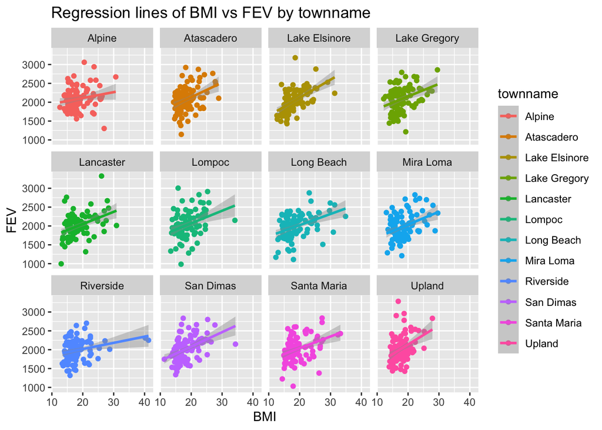

```r
merg %>%
  filter(!(townname %in% NA)) %>%
  ggplot(mapping = aes(x= bmi, y=fev, color=townname))+
  geom_point()+facet_wrap(~townname)+geom_smooth(method = "lm")+
  labs(title="Regression lines of BMI vs FEV by townname", x="BMI",y="FEV")
```

It can be seen from the graphs that there is a positive association between BMI and FEV through all the towns.

##2. Stacked histograms of FEV by BMI category and FEV by smoke/gas exposure. Use different color schemes than the ggplot default.

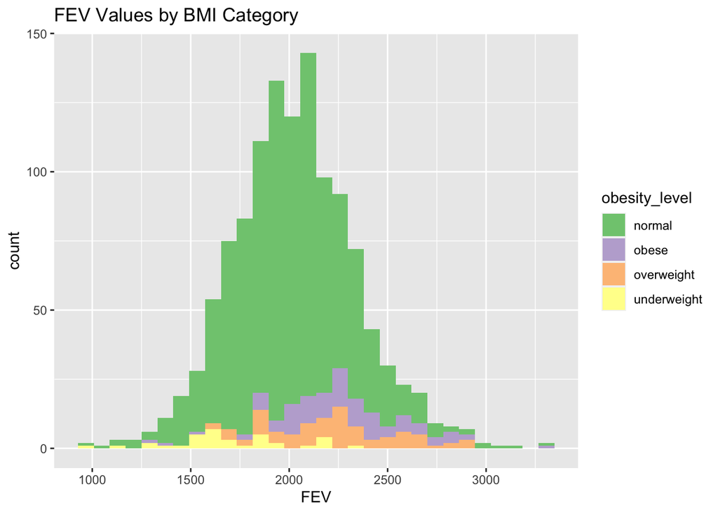

```r
merg %>%
  filter(!(obesity_level %in% NA)) %>%
  ggplot()+
  geom_histogram(mapping = aes(x=fev,fill=obesity_level))+
  labs(title = "FEV Values by BMI Category",x="FEV")+
  scale_fill_brewer(palette="Accent")
```

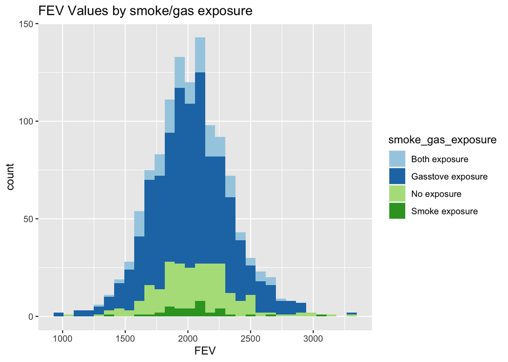

```r
merg %>%
  filter(!(smoke_gas_exposure %in% NA)) %>%
  ggplot()+
  geom_histogram(mapping = aes(x=fev,fill=smoke_gas_exposure))+
  labs(title = "FEV Values by smoke/gas exposure",x="FEV")+
  scale_fill_brewer(palette="Paired")
```

It can be seen that overweight and obese children tend to have higher FEV, while underweight children tend to have lower FEV, compared with children with normal weight. Dissimilarly, FEV does not show strong association with smoke and gas exposure status based on the histograms.

##3. Barchart of BMI by smoke/gas exposure.

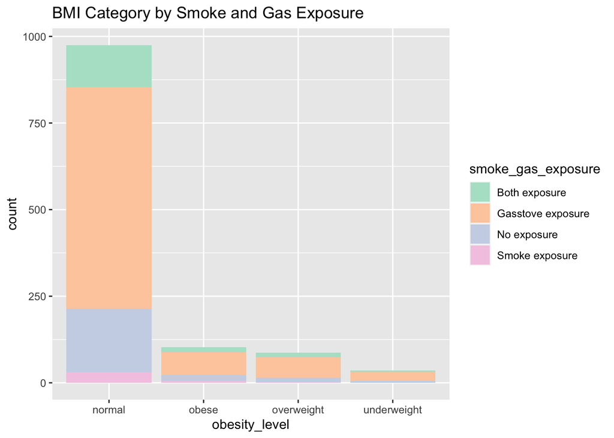

```r
merg %>%
  filter(!(smoke_gas_exposure %in% NA)) %>%
  ggplot()+
  geom_bar(mapping = aes(x = obesity_level, fill = smoke_gas_exposure))+
  labs(title = "BMI Category by Smoke and Gas Exposure")+
  scale_fill_brewer(palette = "Pastel2")
```

The barchart shows that gasstove exposure accounts for the most in children with all kinds of obesity level.

##4. Statistical summary graphs of FEV by BMI and FEV by smoke/gas exposure category.

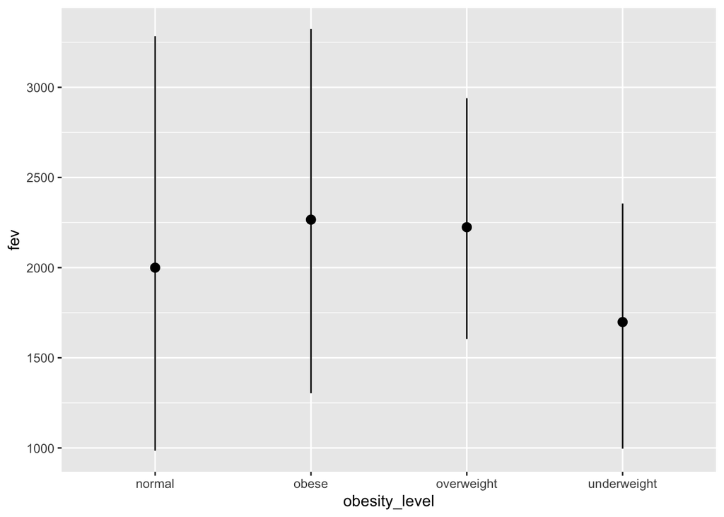

```r
merg %>%
  filter(!(obesity_level %in% NA)) %>%
  ggplot(mapping=aes(x=obesity_level, y=fev))+
  stat_summary(fun.min=min, fun.max=max, fun=mean)
```

```r
  labs(title = "Average FEV by BMI Category")
```

```
## $title
## [1] "Average FEV by BMI Category"
##
## attr(,"class")
## [1] "labels"
```

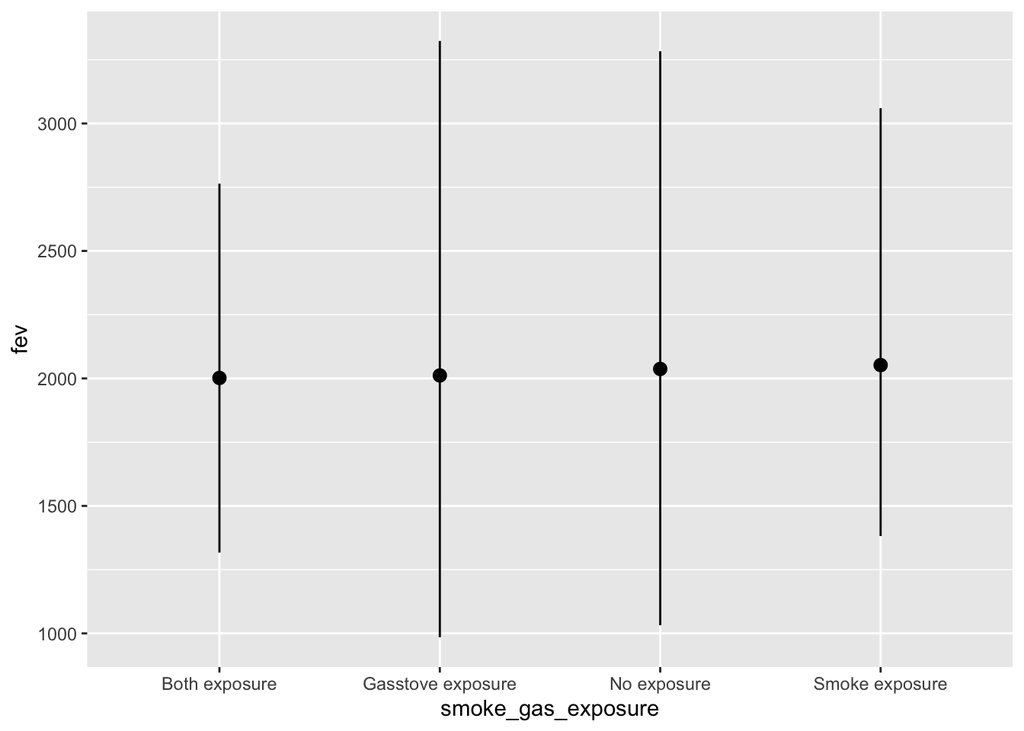

```r
merg %>%
  filter(!(smoke_gas_exposure %in% NA)) %>%
  ggplot(mapping=aes(x=smoke_gas_exposure, y=fev))+
  stat_summary(fun.min=min, fun.max=max, fun=median)
```

```r
  labs(title = "Average FEV by smoke/gas exposure category")
```

```
## $title
## [1] "Average FEV by smoke/gas exposure category"
##
## attr(,"class")
## [1] "labels"
```

Again, we noticed that obese and overweight children have higher mean FEV, and underweight children have lower FEV, compared with children with normal weight. Smoke and gas exposure do not seem to be associated with FEV, which is consistent with the previous conclusion.

##5. A leaflet map showing the concentrations of PM2.5 mass in each of the CHS communities.

```r
pm25_pal = colorNumeric(c('darkgreen','goldenrod','brown'), domain=merg$pm25_mass)
leaflet(merg)%>%
  addProviderTiles("OpenStreetMap")%>%
  addCircles(lat=~lat,lng=~lon,color=~pm25_pal(pm25_mass),opacity=1,fillOpacity=1, radius=500)%>%
addLegend("bottomleft", pal=pm25_pal,values =merg$pm25_mass, title="concentration of PM2.5 Mass in each of the CHS communities", opacity=1)
```

[interactive chart not shown]

##6. Choose a visualization to examine whether PM2.5 mass is associated with FEV.

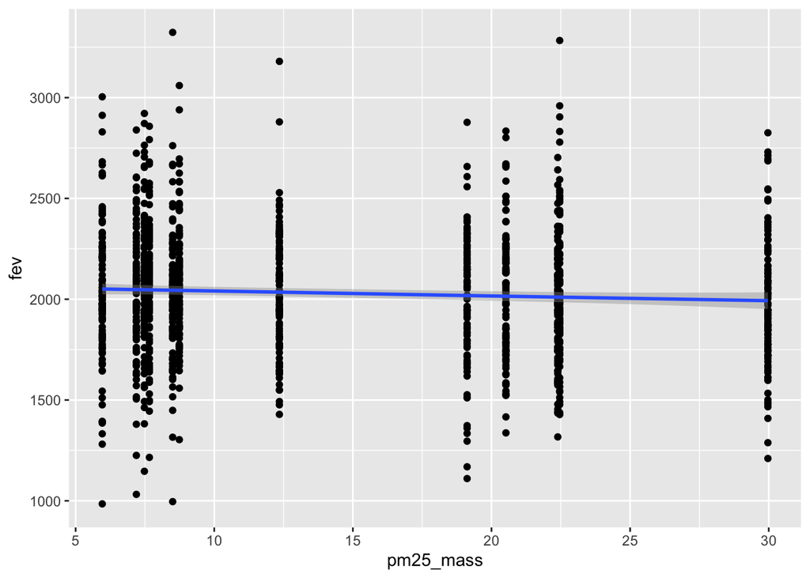

```r
merg %>%
  filter(!(pm25_mass %in% NA)) %>%
  ggplot(mapping = aes(x = pm25_mass,y = fev))+
  geom_point()+
  geom_smooth()
```

It can be seen from the graph that there is a weak negative association between FEV and PM2.5 mass.